# Data Analyst Job Postings Report

Copilot

May 27, 2026

## Introduction

This report summarizes the sample of **400** data analyst job postings. The dataset includes a numeric salary estimate, a minimum years of experience field, and a categorical language requirement field. Because this is a relatively small sample of job postings, the patterns below should be treated as directional rather than definitive.

A quick quality check shows that **317** rows contain a usable minimum experience value and **83** rows are missing that field after parsing or extraction. The average salary estimate is **$71,793.75**, with a median of **$68,000**.

## Minimum Years Experience vs. Median Salary Estimate

[figure not shown]

## Median Salary Estimate by Data Languages

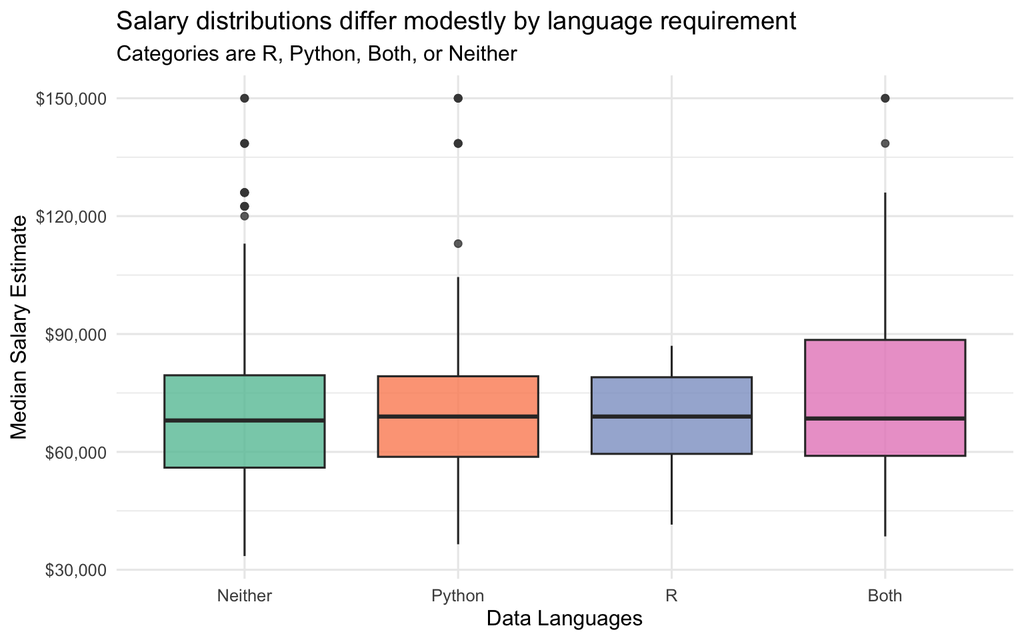

The box plot shows how salary varies across language categories. In this sample, postings that mention both languages often sit at the higher end, while the `Neither` group is broader because it includes many postings that do not explicitly name a language at all. The key limitation is sample size: some categories, especially `R`, contain relatively few postings, so differences in medians and spread should not be over-interpreted.

## Personal Reflection

Using API keys is very useful for automating repetitive tasks and making data collection workflows much faster. Internet access can also be valuable for scraping and gathering additional data, but it should always be handled carefully and responsibly so that the data collection process stays controlled and appropriate.

In this project, a quick quality check is probably enough for our needs. If the remaining errors are scattered rather than systematic, they should have little impact on the overall results. That said, it is still important to check for patterns of bias or consistent extraction mistakes before drawing strong conclusions.